# Lecture 3: Cholesky Decomposition

Author

Joong-Ho Won

Published

March 2026

**Code Output**

```r
library(Matrix)
library(mvtnorm)
library(microbenchmark)
```

## Cholesky Decomposition

- Named after [André-Louis Cholesky, 1875-1918](https://en.wikipedia.org/wiki/André-Louis_Cholesky).
- Our mantra 2:

> **The structure should be exploited whenever possible in solving a problem.**

Common structures include: symmetry, positive (semi)definiteness, sparsity, Kronecker product, low rank, …

- Recall that a matrix $M$ is positive (semi)definite if
  $$\mathbf{x}^T\mathbf{M}\mathbf{x} > 0 ~(\ge 0), \quad \forall \mathbf{x}\neq\mathbf{0}.$$
- We can always assume that a postive (semi)definite matrix is symmetric (why?)
- Example: normal equation
  $$\mathbf{X}^T \mathbf{X} \beta = \mathbf{X}^T \mathbf{y}$$
  for linear regression, the coefficient matrix $\mathbf{X}^T \mathbf{X}$ is symmetric and positive semidefinite. How to exploit this structure?
- Most of time statisticians deal with positive (semi)definite matrices.

```r
for (k in seq_len(n)) {
    for (j in k + seq_len(n - k)) {
        a_jk_div_a_kk <- A[j, k] / A[k, k]
        for (i in j - 1 + seq_len(n - j + 1)) {
            A[i, j] <- A[i, j] - A[i, k] * a_jk_div_a_kk    # L_22
        }
    }
    sqrt_akk <- sqrt(A[k, k])
    for (i in k - 1 + seq_len(n - k + 1)) {
        A[i, k] = A[i, k] / sqrt_akk    # l_11 and b
    }
}
```

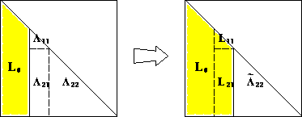

Source: http://www.netlib.org

- Computational cost:
  $$\frac{1}{2} [2(n-1)^2 + 2(n-2)^2 + \cdots + 2 \cdot 1^2] \approx \frac{1}{3} n^3 \quad \text{flops}$$
  plus $n$ square roots. **Half** the cost of LU decomposition.
- In general Cholesky decomposition is very stable. Failure of the decomposition simply means $\mathbf{A}$ is not positive definite. **It is an efficient way to test positive definiteness.**

## Pivoting

- Pivoting is only needed if you want the Cholesky factor of a positive *semidefinite* matrix.
- When $\mathbf{A}$ does not have full rank, e.g., $\mathbf{X}^T \mathbf{X}$ with a non-full column rank $\mathbf{X}$, we encounter $a_{kk} = 0$ during the procedure.
- **Symmetric pivoting**. At each stage $k$, we permute both row and column such that $\max_{k \le i \le n} a_{ii}$ becomes the pivot. If we encounter $\max_{k \le i \le n} a_{ii} = 0$, then $\mathbf{A}[k:n,k:n] = \mathbf{0}$ (why?) and the algorithm terminates.
- With symmetric pivoting:
  $$\mathbf{P} \mathbf{A} \mathbf{P}^T = \mathbf{L} \mathbf{L}^T,$$
  where $\mathbf{P}$ is a permutation matrix and $\mathbf{L} \in \mathbb{R}^{n \times r}$, $r = \text{rank}(\mathbf{A})$.

## Implementation

- LAPACK functions: [`dpotrf`](http://www.netlib.org/lapack/explore-html/d1/d7a/group__double_p_ocomputational_ga2f55f604a6003d03b5cd4a0adcfb74d6.html#ga2f55f604a6003d03b5cd4a0adcfb74d6) (without pivoting), [`dpstrf`](http://www.netlib.org/lapack/explore-html/da/dba/group__double_o_t_h_e_rcomputational_ga31cdc13a7f4ad687f4aefebff870e1cc.html#ga31cdc13a7f4ad687f4aefebff870e1cc) (with pivoting).
- R functions: `base::chol()` or `Matrix::chol()` (gives an **upper** triangular factor: $A = R^T R$)

## Example: positive definite matrix

```r
A <- t(Matrix(c(4, 12, -16, 12, 37, -43, -16, -43, 98), nrow=3))  # check out this is pd!
A
```

**Code Output**

```
3 x 3 Matrix of class "dsyMatrix"
     [,1] [,2] [,3]
[1,]    4   12  -16
[2,]   12   37  -43
[3,]  -16  -43   98
```

```r
# Cholesky without pivoting
Achol <- Matrix::chol(Matrix::symmpart(A))
Achol
```

**Code Output**

```
3 x 3 Matrix of class "dtrMatrix"
     [,1] [,2] [,3]
[1,]    2    6   -8
[2,]    .    1    5
[3,]    .    .    3
```

```r
class(Achol)
```

**Code Output**

```
[1] "dtrMatrix"
attr(,"package")
[1] "Matrix"
```

```r
getSlots("Cholesky")
```

**Code Output**

```
       uplo           x        perm         Dim    Dimnames
"character"   "numeric"   "integer"   "integer"      "list"
```

```r
str(Achol)
```

**Code Output**

```
Formal class 'dtrMatrix' [package "Matrix"] with 5 slots
  ..@ Dim     : int [1:2] 3 3
  ..@ Dimnames:List of 2
  .. ..$ : NULL
  .. ..$ : NULL
  ..@ x       : num [1:9] 2 0 0 6 1 0 -8 5 3
  ..@ uplo    : chr "U"
  ..@ diag    : chr "N"
```

```r
b <- c(1.0, 2.0, 3.0)
solve(A, b) # this does LU; wasteful!; 2/3 n^3 + 2n^2
```

**Code Output**

```
[1] 28.583333 -7.666667  1.333333
```

```r
y <- solve(t(Achol), b) # two triangular solves; only 2n^2 flops
solve(Achol, y)
```

**Code Output**

```
[1] 28.583333 -7.666667  1.333333
```

```r
det(A) # this actually does LU; wasteful!
```

**Code Output**

```
[1] 36
```

```r
det(Achol)^2 # cheap
```

**Code Output**

```
[1] 36
```

```r
solve(A) # this does LU!
```

**Code Output**

```
3 x 3 Matrix of class "dsyMatrix"
           [,1]        [,2]       [,3]
[1,]  49.361111 -13.5555556  2.1111111
[2,] -13.555556   3.7777778 -0.5555556
[3,]   2.111111  -0.5555556  0.1111111
```

```r
solve(Achol, solve(t(Achol))) # 2n triangular solves
```

**Code Output**

```
3 x 3 Matrix of class "dgeMatrix"
           [,1]        [,2]       [,3]
[1,]  49.361111 -13.5555556  2.1111111
[2,] -13.555556   3.7777778 -0.5555556
[3,]   2.111111  -0.5555556  0.1111111
```

## Example: positive *semi*definite matrix

```r
(A <- Matrix(c(1,1,.5,1,1,.5,.5,.5,1), nrow=3))
```

**Code Output**

```
3 x 3 Matrix of class "dsyMatrix"
     [,1] [,2] [,3]
[1,]  1.0  1.0  0.5
[2,]  1.0  1.0  0.5
[3,]  0.5  0.5  1.0
```

```r
eigen(A, symmetric = TRUE)$values
```

**Code Output**

```
[1] 2.3660254 0.6339746 0.0000000
```

```r
Matrix::chol(A, pivot=FALSE) # 2nd argument requests pivoting
```

**Code Output**

```
Error in `.local()`:
! LAPACK routine 'dpotrf': leading principal minor of order 2 is not positive
```

```r
(Achol <- base::chol(A, pivot=TRUE)) # turn off checking pd
```

**Code Output**

**Code Output**

```
     [,1]      [,2] [,3]
[1,]    1 0.5000000    1
[2,]    0 0.8660254    0
[3,]    0 0.0000000    0
attr(,"pivot")
[1] 1 3 2
attr(,"rank")
[1] 2
```

```r
attr(Achol, "pivot")
```

**Code Output**

```
[1] 1 3 2
```

```r
attr(Achol, "rank")
```

**Code Output**

```
[1] 2
```

```r
Matrix::rankMatrix(A) # determine rank from SVD, which is more numerically stable
```

**Code Output**

```
[1] 2
attr(,"method")
[1] "tolNorm2"
attr(,"useGrad")
[1] FALSE
attr(,"tol")
[1] 6.661338e-16
```

```r
Achol[, attr(Achol, "pivot")]
```

**Code Output**

```
     [,1] [,2]      [,3]
[1,]    1    1 0.5000000
[2,]    0    0 0.8660254
[3,]    0    0 0.0000000
```

```r
(P <- as(attr(Achol, "pivot"), "pMatrix"))   # permutation matrix, actually P' in our notation
```

**Code Output**

```
3 x 3 sparse Matrix of class "pMatrix"

[1,] | . .
[2,] . . |
[3,] . | .
```

```r
# P A P' = L L'
Matrix::norm(t(P) %*% A %*% P - t(Achol) %*% Achol, type="F")  # Frobenius norm
```

**Code Output**

```
[1] 1.110223e-16
```

## Applications

- **No inversion** principle: whenever we see matrix inverse, we should think in terms of solving linear equations. If the matrix is positive (semi)definite, use Cholesky decomposition, which is twice cheaper than LU decomposition.

### Multivariate normal density

Multivariate normal density $\mathcal{N}(0, \Sigma)$, where $\Sigma$ is $n\times n$ positive definite, is
$$\frac{1}{(2\pi)^{n/2}\det(\Sigma)^{1/2}}\exp\left(-\frac{1}{2}\mathbf{y}^T\Sigma^{-1}\mathbf{y}\right).$$

Hence the log likelihood is
$$- \frac{n}{2} \log (2\pi) - \frac{1}{2} \log \det \Sigma - \frac{1}{2} \mathbf{y}^T \Sigma^{-1} \mathbf{y}.$$

- Method 1:
  1. compute explicit inverse $\Sigma^{-1}$ ($2n^3$ flops),
  2. compute quadratic form ($2n^2 + 2n$ flops),
  3. compute determinant ($2n^3/3$ flops).
- Method 2:
  1. Cholesky decomposition $\Sigma = \mathbf{L} \mathbf{L}^T$ ($n^3/3$ flops),
  2. Solve $\mathbf{L} \mathbf{x} = \mathbf{y}$ by forward substitutions ($n^2$ flops),
  3. compute quadratic form $\mathbf{x}^T \mathbf{x}$ ($2n$ flops), and
  4. compute determinant from Cholesky factor ($n$ flops).

**Which method is better?**

```r
# word-by-word transcription of mathematical expression
# Matrix::determinant computes the logarithm of the determinant
logpdf_mvn_1 <- function(y, Sigma) {
    n <- length(y)
    - (n / 2) * log(2 * pi) - (1 / 2) * Matrix::determinant(Sigma)$modulus - (1 / 2) * t(y) %*% solve(Sigma) %*% y
}

# you learnt why you should avoid inversion
logpdf_mvn_2 <- function(y, Sigma) {
    n <- length(y)
    Sigmachol <- Matrix::chol(Matrix::symmpart(Sigma))
    - (n / 2) * log(2 * pi) - Matrix::determinant(Sigmachol)$modulus - (1 / 2) * sum(abs(solve(t(Sigmachol), y))^2)
}

# this is for the efficiency-concerned
logpdf_mvn_3 <- function(y, Sigma) {
    n <- length(y)
    Sigmachol <- Matrix::chol(Matrix::symmpart(Sigma))
    - 0.5 * n * log(2 * pi) - sum(log(diag(Sigmachol))) - 0.5 * sum(abs(solve(t(Sigmachol), y))^2)
}
```

```r
set.seed(123) # seed

n <- 1000
# a pd matrix
Sigma_half <- Matrix(rnorm(n * (2 * n)), nrow=n)
Sigma <- Sigma_half %*% t(Sigma_half)
Sigma <- Matrix::symmpart(Sigma)
Sigmachol <- Matrix::chol(Sigma)

y <- Sigmachol %*% rnorm(n)  # one random sample from N(0, Sigma). Homework

# at least they give same answer
(logpdf_mvn_1(y, Sigma))
```

**Code Output**

```
1 x 1 Matrix of class "dgeMatrix"
          [,1]
[1,] -5272.565
```

```r
(logpdf_mvn_2(y, Sigma))
```

**Code Output**

```
[1] -5272.565
attr(,"logarithm")
[1] TRUE
```

```r
(logpdf_mvn_3(y, Sigma))
```

**Code Output**

```
[1] -5272.565
```

```r
res <- microbenchmark::microbenchmark(logpdf_mvn_1(y, Sigma), logpdf_mvn_2(y, Sigma), logpdf_mvn_3(y, Sigma))
print(res)
```

**Code Output**

```
Unit: milliseconds
                   expr       min        lq      mean    median        uq
 logpdf_mvn_1(y, Sigma) 23.325646 24.286506 27.532287 24.636781 25.980450
 logpdf_mvn_2(y, Sigma)  4.123613  5.634106  6.243275  5.800406  6.088484
 logpdf_mvn_3(y, Sigma)  3.977110  5.616983  7.466599  5.792466  6.352907
      max neval
 137.3165   100
  15.0315   100
 113.5574   100
```

- To evaluate same multivariate normal density at many observations $y_1, y_2, \ldots$, we pre-compute the Cholesky decomposition ($n^3/3$ flops), then each evaluation costs $n^2$ flops.

## Linear regression by Cholesky

- Cholesky decomposition is **one** approach to solve linear regression. Assume $\mathbf{X} \in \mathbb{R}^{n \times p}$ and $\mathbf{y} \in \mathbb{R}^n$.
  - Compute $\mathbf{X}^T \mathbf{X}$: $np^2$ flops
  - Compute $\mathbf{X}^T \mathbf{y}$: $2np$ flops
  - Cholesky decomposition of $\mathbf{X}^T \mathbf{X}$: $\frac{1}{3} p^3$ flops
  - Solve normal equation $\mathbf{X}^T \mathbf{X} \beta = \mathbf{X}^T \mathbf{y}$: $2p^2$ flops
  - If need standard errors, another $(4/3)p^3$ flops

Total computational cost is $np^2 + (1/3) p^3$ (without s.e.) or $np^2 + (5/3) p^3$ (with s.e.) flops.